# Pitfall 1. Over-interpretation of the overlap of differentially-expressed genes

Bohan Zhang, Audran Feuvrier

27 November 2026

```r
suppressPackageStartupMessages({
  library(sechm)          # heatmap visualization
  library(edgeR)          # differential expression analysis
  library(dplyr)
  library(ComplexHeatmap)
  library(stageR)         # stage-wise multiple testing correction
  library(ggplotify)
  library(ggplot2)
  library(ggvenn)         # Venn diagrams
  library(cowplot)        # multi-panel figure assembly
  library(magick)
})
# set working directory and load helper functions
wd <- "/mnt/gapp/work/bohan/transcriptional_sex_difference_analysis_pitfalls/bohan_ver"
setwd(wd)
knitr::opts_knit$set(root.dir = wd)
knitr::opts_chunk$set(warning = FALSE, class.message = "msg")
source("./code/function.R")
```

# 1 Full dataset

## 1.1 Get the dataset

We load the dataset as a [SummarizedExperiment](https://bioconductor.org/packages/3.23/bioc/vignettes/SummarizedExperiment/inst/doc/SummarizedExperiment.html) object:

```r
se <- readRDS("./datasets/whole_vHC_dataset.rds")
```

In this dataset, we have 122 ventral hippocampus samples from female and male mice (`Sex`: Female/Male) subjected to either forced swim stress or control conditions (`Condition`: Stress/Ctrl). This dataset combines multiple independent experiments from Floriou-Servou et al. (2018), von Ziegler et al. (2022), and Privitera et al. (2024):

```r
summary(as.data.frame(colData(se)[,c("Experiment", "Condition", "Sex")]))
```

```
##              Experiment  Condition      Sex
##  Floriou-servou.E1:16   Ctrl  :61   Male  :94
##  Floriou-servou.E2:10   Stress:61   Female:28
##  Privitera.E1     :17
##  Privitera.E2     :32
##  vonZiegler.E1    :16
##  vonZiegler.E2    :12
##  vonZiegler.E3    :19
```

## 1.2 Split females and males, and conduct differential analysis separately

Perform differential expression analysis (DEA) independently in each sex, then compare the resulting DEG lists.

```r
# For Males
se_M <- se[,se$Sex == "Male"]

# create an edgeR object, storing count data and associated sample information
dge_M <- DGEList(counts = assay(se_M, "counts"))

 # calculate TMM normalization factors to correct for differences in library composition between samples
dge_M <- calcNormFactors(dge_M)

# design matrix describing the comparison of interest.
# Here we test the effect of Stress vs. Ctrl
mm <- model.matrix(~Condition, data = as.data.frame(colData(se_M)))

# remove genes with low expression (low-count genes provide little statistical power, lead to unreliable dispersion estimates, and inflate false discovery rates)
keep <- filterByExpr(dge_M, mm, min.count = 10)
dge_M <- dge_M[keep,] # subset the lowly expressed genes out of se
se_M <- se_M[rownames(dge_M), ]
dge_M <- estimateDisp(dge_M, mm) # estimate dispersion

# # Optional: Visual exploration of data using MDS plot:
# mds <- plotMDS(dge_M, plot=FALSE)
# mds <- cbind(as.data.frame(colData(se_M)), x=mds$x, y=mds$y)
# ggplot(mds, aes(x,y,colour=Condition)) + geom_point()
# ggplot(mds, aes(x,y,colour=Experiment)) + geom_point()

# For females: similar process as above
se_F <- se[,se$Sex == "Female"]
dge_F <- DGEList(counts = assay(se_F, "counts"))
dge_F <- calcNormFactors(dge_F)
mm <- model.matrix(~Condition, data = as.data.frame(colData(se_F)))
keep <- filterByExpr(dge_F, mm, min.count = 10)
dge_F <- dge_F[keep,]
se_F <- se_F[rownames(dge_F), ]
dge_F <- estimateDisp(dge_F, mm)

# # Optional: Visual exploration of data using MDS plot:
# mds <- plotMDS(dge_F, plot=FALSE)
# mds <- cbind(as.data.frame(colData(se_F)), x=mds$x, y=mds$y)
# ggplot(mds, aes(x,y,colour=Condition)) + geom_point()
# ggplot(mds, aes(x,y,colour=Experiment)) + geom_point()
```

Surrogate variable analysis to identify hidden sources of unwanted variation (see (Leek and Storey 2007; Leek et al. 2012))

```r
set.seed(1)
# as a rule of thumb, we run sva using both estimators of the number of SVs, and
# take the smallest of the two
# se_M <- SEtools::svacor(se_M, ~0 + Condition, numSVmethod="leek", method = "vst")
# se_M <- SEtools::svacor(se_M, ~0 + Condition, numSVmethod="be", method = "vst")
#
# se_F <- SEtools::svacor(se_F, ~0 + Condition, numSVmethod="leek", method = "vst")
# se_F <- SEtools::svacor(se_F, ~0 + Condition, numSVmethod="be", method = "vst")

# Use the suggested number of SVs for each subsets

se_M <- SEtools::svacor(se_M, ~ 0 + Condition, n.sv = 6, method = "vst")
```

```
## Using variance-stabilizing transformation
```

```
## Number of significant surrogate variables is:  6
## Iteration (out of 5 ):1  2  3  4  5
```

```r
# pp <- plotMDS(assay(se_M, "corrected"), plot=FALSE)
# mds <- cbind(as.data.frame(colData(se_M)), x=pp$x, y=pp$y)
# ggplot(mds, aes(x,y,shape=Sex,colour=Condition)) + geom_point()
# ggplot(mds, aes(x,y,colour=Experiment)) + geom_point()

se_F <- SEtools::svacor(se_F, ~ 0 + Condition, n.sv = 2, method = "vst")
```

```
## Using variance-stabilizing transformation
```

```
## Number of significant surrogate variables is:  2
## Iteration (out of 5 ):1  2  3  4  5
```

```r
# pp <- plotMDS(assay(se_F, "corrected"), plot=FALSE)
# mds <- cbind(as.data.frame(colData(se_F)), x=pp$x, y=pp$y)
# ggplot(mds, aes(x,y,shape=Sex,colour=Condition)) + geom_point()
# ggplot(mds, aes(x,y,colour=Experiment)) + geom_point()
```

Perform DEA in each subset independently

```r
# For males
# Compute log2FC changes relative to Ctrls. This assay will later be used for visualization
se_M <- log2FC(se_M, "corrected", controls=grep("Ctrl", se_M$Condition))

# Incorporate Condition and surrogate variables (SVs) into the design matrix
formula <- paste(grep("^SV[0-9]", colnames(colData(se_M)), value = TRUE), collapse = "+")
formula <- as.formula(paste0("~", formula, "+Condition"))
mm <- model.matrix(formula, data = as.data.frame(colData(se_M)))
dge_M <- calcNormFactors(DGEList(assay(se_M)))  # calculate TMM normalization factor
dge_M <- estimateDisp(dge_M, mm)  # estimate dispersion

# Fit quasi-likelihood negative-binomial models
fit_M <- glmQLFit(dge_M, mm, prior.count = 0.5)

Results_stress_M <- addlogFCSE(as.data.frame(topTags(glmQLFTest(fit_M, "ConditionStress"),Inf)))
# Results_stress_M selects "ConditionStress"
# Answering the question: is there any Stress effect in males


# For females: similar approach
se_F <- log2FC(se_F, "corrected", controls=grep("Ctrl", se_F$Condition))
formula <- paste(grep("^SV[0-9]", colnames(colData(se_F)), value = TRUE), collapse = "+")
formula <- as.formula(paste0("~", formula, "+Condition"))
mm <- model.matrix(formula, data = as.data.frame(colData(se_F)))
dge_F <- calcNormFactors(DGEList(assay(se_F)))
dge_F <- estimateDisp(dge_F, mm)
fit_F <- glmQLFit(dge_F, mm, prior.count=0.5)

Results_stress_F <- addlogFCSE(as.data.frame(topTags(glmQLFTest(fit_F, "ConditionStress"),Inf)))
# Results_stress_F selects "ConditionStress"
# Answering the question: is there any Stress effect in females
```

Now let’s compare the DEG lists from two independent analysis

```r
# Significant stress DEGs
M_signif <- clean_name(rownames(Results_stress_M[Results_stress_M$FDR < 0.05,]))
F_signif <- clean_name(rownames(Results_stress_F[Results_stress_F$FDR < 0.05,]))

# Find gene unique to M and F
unique_to_M <- setdiff(M_signif, F_signif)  # genes significant only in males. Often interpreted as "male-specific"
unique_to_F <- setdiff(F_signif, M_signif)  # genes significant only in females. Often interpreted as "female-specific"
both_signif <- intersect(M_signif, F_signif) # genes significant in both sexes

# Prepare for visualization
genes_list <- list("Significant\nin males" = unique_to_M,
                    "Significant\nin females" = unique_to_F,
                    "Significant\nin both" = both_signif)
genes_df <- data.frame(
  belongTo = rep(names(genes_list), lengths(genes_list)),
  row.names = unlist(genes_list)
)
rownames(se_M) <- clean_name(rownames(se_M))
rownames(se_F) <- clean_name(rownames(se_F))
se_M_F <- SEtools::mergeSEs(list(se_M, se_F), do.scale = F, keepRowData = F)
metadata(se_M_F)$hmcols <- c("darkblue", "white", "darkred")
DEGs <- intersect(union(F_signif, M_signif), rownames(se_M_F))
# Annotate DEGs
rowData(se_M_F)$belongTo <- factor(genes_df$belongTo[match(rownames(se_M_F), rownames(genes_df))], levels = c("Significant\nin both", "Significant\nin females", "Significant\nin males"))
# change female to first sex (for the figure)
se_M_F <- se_M_F[, order(se_M_F$Condition, se_M_F$Sex == "Male")]
```

## 1.3 Visualization

### 1.3.1 Fig 1B

```r
fig1b <- ggvenn(list("Significant\nin females" = F_signif, "Significant\nin males" = M_signif),
              fill_color  = c("Significant\nin females" = "#40B0A6", "Significant\nin males" = "#E1BE61"),
              auto_scale = T,
              set_name_size = 0, set_name_color = "white") +
         annotate("text", x = -1.3, y = 0.85, label = "Significant\nin females", size = 3.5) +
         annotate("text", x = 1.45, y = 0.85, label = "Significant\nin males", size = 3.5) +
         coord_fixed(clip = "off")
```

```
## ℹ Adding new coordinate system, which will replace the existing one.
```

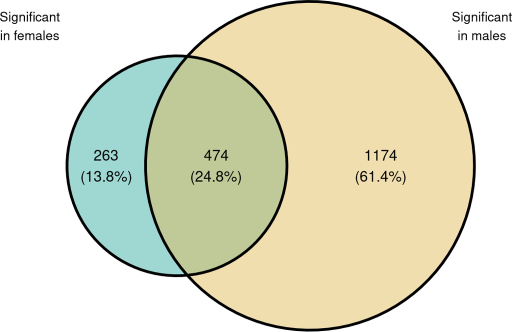

```r
fig1b
```

### 1.3.2 Fig 1D

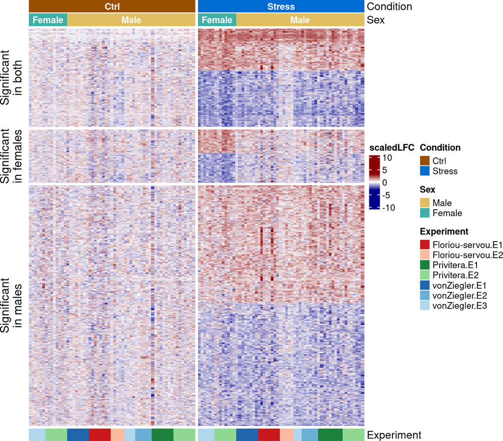

```r
fig1d <- sechm(
    se = se_M_F,
    features = DEGs,
    assayName = "scaledLFC",
    gaps_at = c("Condition"),
    gaps_row = "belongTo",
    top_annotation = c("Condition", "Sex"),
    anno_labels = c("Condition", "Sex"),
    anno_label_gp = c(size = 10, col = "white"),
    bottom_annotation = c("Experiment"),
    column_title = NULL,
    cluster_rows = TRUE,
    cluster_row_slices = FALSE,
    show_row_dend = FALSE,
    annorow_title_side = NULL,
    use_raster = TRUE
    )
fig1d
```

# 2 Reduced dataset

In the second section, we repeat the same analysis process using a smaller subset of data. It contrains balanced number of female and males samples. Only one experiment is included.

## 2.1 Get the dataset

```r
se <- readRDS("./datasets/small_vHC.rds")
```

## 2.2 Split females and males, and conduct differential analysis separately

```r
# FOR MALES
se_M <- se[,se$Sex == "Male"]
dge_M <- DGEList(counts = assay(se_M, "counts"))
dge_M <- calcNormFactors(dge_M)
mm <- model.matrix(~Condition, data = as.data.frame(colData(se_M)))
keep <- filterByExpr(dge_M, mm, min.count = 10)
dge_M <- dge_M[keep,] # subset the lowly expressed genes out of se
se_M <- se_M[rownames(dge_M), ]
dge_M <- estimateDisp(dge_M, mm) #estimate dispersion

# # Visual exploration of data:
# mds <- plotMDS(dge_M, plot=FALSE)
# mds <- cbind(as.data.frame(colData(se_M)), x=mds$x, y=mds$y)
# ggplot(mds, aes(x,y,colour=Condition)) + geom_point()

# FOR FEMALES
se_F <- se[,se$Sex == "Female"]
dge_F <- DGEList(counts = assay(se_F, "counts"))
dge_F <- calcNormFactors(dge_F)
mm <- model.matrix(~Condition, data = as.data.frame(colData(se_F)))
keep <- filterByExpr(dge_F, mm, min.count = 10)
dge_F <- dge_F[keep,]
# subset the lowly expressed genes out of se
se_F <- se_F[rownames(dge_F), ]
dge_F <- estimateDisp(dge_F, mm) #estimate dispersion

# #Visual exploration of data:
# mds <- plotMDS(dge_F, plot=FALSE)
# mds <- cbind(as.data.frame(colData(se_F)), x=mds$x, y=mds$y)
# ggplot(mds, aes(x,y,colour=Condition)) + geom_point()
```

Surrogate variable analysis to identify hidden sources of unwanted variation

```r
set.seed(3)

se_M <- SEtools::svacor(se_M, ~0 + Condition, numSVmethod="leek", method = "vst")
```

```
## Using variance-stabilizing transformation
```

```
## No significant surrogate variables
```

```
## Nothing to do!
```

```r
se_M <- SEtools::svacor(se_M, ~0 + Condition, numSVmethod="be", method = "vst")
```

```
## Using variance-stabilizing transformation
```

```
## Number of significant surrogate variables is:  1
## Iteration (out of 5 ):1  2  3  4  5
```

```r
se_F <- SEtools::svacor(se_F, ~0 + Condition, numSVmethod="leek", method = "vst")
```

```
## Using variance-stabilizing transformation
```

```
## No significant surrogate variables
```

```
## Nothing to do!
```

```r
se_F <- SEtools::svacor(se_F, ~0 + Condition, numSVmethod="be", method = "vst")
```

```
## Using variance-stabilizing transformation
```

```
## Number of significant surrogate variables is:  1
## Iteration (out of 5 ):1  2  3  4  5
```

```r
# Use the suggested number of SVs for each subsets

se_M <- SEtools::svacor(se_M, ~0 + Condition, n.sv = 1, method = "vst")
```

```
## Using variance-stabilizing transformation
```

```
## Number of significant surrogate variables is:  1
## Iteration (out of 5 ):1  2  3  4  5
```

```r
# pp <- plotMDS(assay(se_M,"corrected"), plot=FALSE)
# mds <- cbind(as.data.frame(colData(se_M)), x=pp$x, y=pp$y)
# ggplot(mds, aes(x,y,shape=Sex,colour=Condition)) + geom_point()

se_F <- SEtools::svacor(se_F, ~0 + Condition, n.sv = 1, method = "vst")
```

```
## Using variance-stabilizing transformation
```

```
## Number of significant surrogate variables is:  1
## Iteration (out of 5 ):1  2  3  4  5
```

```r
# pp <- plotMDS(assay(se_F,"corrected"), plot=FALSE)
# mds <- cbind(as.data.frame(colData(se_F)), x=pp$x, y=pp$y)
# ggplot(mds, aes(x,y,shape=Sex,colour=Condition)) + geom_point()
```

Perform DEA in both subset independently

```r
# For males
se_M <- log2FC(se_M, "corrected", controls=grep("Ctrl", se_M$Condition))
formula <- paste(grep("^SV[0-9]", colnames(colData(se_M)), value = TRUE), collapse = "+")
formula <- as.formula(paste0("~", formula, "+Condition"))
mm <- model.matrix(formula, data = as.data.frame(colData(se_M)))
dge_M <- calcNormFactors(DGEList(assay(se_M)))
dge_M <- estimateDisp(dge_M, mm)
fit_M <- glmQLFit(dge_M, mm, prior.count=0.5)

Results_stress_M <- addlogFCSE(as.data.frame(topTags(glmQLFTest(fit_M, "ConditionStress"),Inf)))
# Results_stress_M selects "ConditionStress"
# Answering the question: is there any Stress effect in males (becase male is the reference sex)


# For females
se_F <- log2FC(se_F, "corrected", controls=grep("Ctrl", se_F$Condition))
formula <- paste(grep("^SV[0-9]", colnames(colData(se_F)), value = TRUE), collapse = "+")
formula <- as.formula(paste0("~", formula, "+Condition"))
mm <- model.matrix(formula, data = as.data.frame(colData(se_F)))
dge_F <- calcNormFactors(DGEList(assay(se_F)))
dge_F <- estimateDisp(dge_F, mm)
fit_F <- glmQLFit(dge_F, mm, prior.count=0.5)

Results_stress_F <- addlogFCSE(as.data.frame(topTags(glmQLFTest(fit_F, "ConditionStress"),Inf)))
# Results_stress_F selects "ConditionStress"
# Answering the question: is there any Stress effect in females (becase female is the reference sex)
```

Compare the DEG lists from two independent analysis

```r
# Significant stress DEGs
M_signif <- clean_name(rownames(Results_stress_M[Results_stress_M$FDR < 0.05,]))
F_signif <- clean_name(rownames(Results_stress_F[Results_stress_F$FDR < 0.05,]))

# Find gene unique to M and F
unique_to_M <- setdiff(M_signif, F_signif)
unique_to_F <- setdiff(F_signif, M_signif)
both_signif = intersect(M_signif, F_signif)

# Prepare for visualization
genes_list <- list("Significant\nin males" = unique_to_M,
                     "Significant\nin females" = unique_to_F,
                     "Significant\nin both" = both_signif)

genes_df <- data.frame(
  belongTo = rep(names(genes_list), lengths(genes_list)),
  row.names = unlist(genes_list)
)
rownames(se_M) <- clean_name(rownames(se_M))
rownames(se_F) <- clean_name(rownames(se_F))
se_M_F = SEtools::mergeSEs(list(se_M, se_F), do.scale = F, keepRowData = F)
metadata(se_M_F)$hmcols <- c("darkblue", "white", "darkred")
DEGs <- intersect(union(F_signif, M_signif), rownames(se_M_F))
# Annotate DEGs
rowData(se_M_F)$belongTo <- factor(genes_df$belongTo[match(rownames(se_M_F), rownames(genes_df))], levels = c("Significant\nin both", "Significant\nin females", "Significant\nin males"))
# change female to first sex (for the figure)
se_M_F <- se_M_F[, order(se_M_F$Condition, se_M_F$Sex == "Male")]
```

## 2.3 Visualization

### 2.3.1 Fig 1C

```r
fig1c <- ggvenn(list("Significant\nin females" = F_signif, "Significant\nin males" = M_signif),
              fill_color  = c("Significant\nin females" = "#40B0A6", "Significant\nin males" = "#E1BE61"),
              auto_scale = T,
              set_name_size = 0, set_name_color = "white") +
         annotate("text", x = -1.6, y = 0.85, label = "Significant\nin females", size = 3.5) +
         annotate("text", x = 1.6, y = 0.85, label = "Significant\nin males", size = 3.5) +
         coord_fixed(clip = "off")
```

```
## ℹ Adding new coordinate system, which will replace the existing one.
```

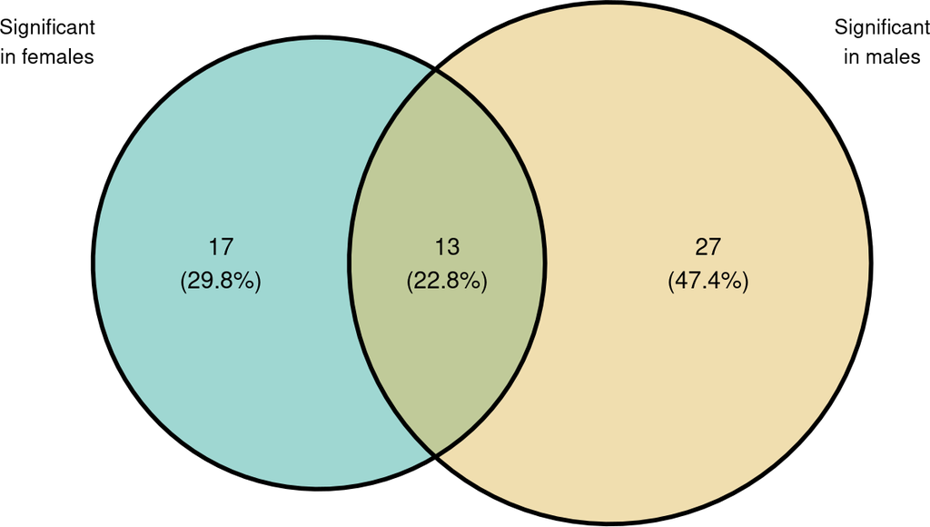

```r
fig1c
```

### 2.3.2 Fig 1E

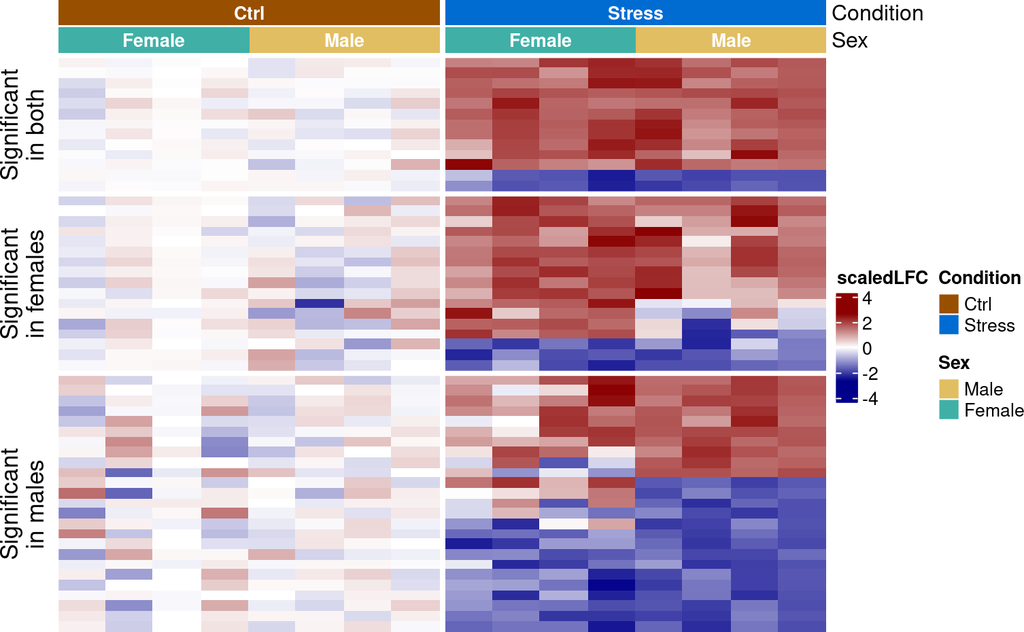

```r
fig1e <- sechm(
    se = se_M_F,
    features = DEGs,
    assayName = "scaledLFC",
    gaps_at = c("Condition"),
    gaps_row = "belongTo",
    top_annotation = c("Condition", "Sex"),
    anno_labels = c("Condition", "Sex"),
    anno_label_gp = c(size = 10, col = "white"),
    column_title = NULL,
    use_raster = TRUE,
    cluster_rows = TRUE,
    cluster_row_slices = FALSE,
    show_row_dend = FALSE,
    annorow_title_side = NULL)
fig1e
```